# Radioactivity_OnG

William Zhang

2023-06-06

*Source*: https://www.epa.gov/radtown/radioactive-waste-material-oil-and-gas-drilling Radionuclides commonly found in TENORM are radium, radon, uranium, potassium and thorium.

*Source*: https://www.nrdc.org/bio/bemnet-alemayehu/radioactive-material-oil-and-gas-industry#:~:text=When%20it%20comes%20to%20oil,%2D226%20and%20Radium%2D228. When it comes to oil and gas exploration and production, the greatest radiation health risk is cancer due to exposure to Radium-226 and Radium-228. Underground oil and gas reservoirs often contain elevated levels of radioactive materials in comparison with that found aboveground, mostly Radium-226 and Radium-228. Once drilling begins, radioactive materials that would have otherwise been confined beneath the surface can be released into the air, onto land, or into surface water or groundwater. As they become concentrated, it leads to environmental contamination and can accumulate in people’s bodies.

Radium also decays into radon isotopes and, when inhaled, deposit radiation in lungs, causing lung cancer. In fact, radon is the second-leading cause of lung cancer in the U. S. Radon decay products, including lead-210 and polonium-210, are also present in high levels in gas handling equipment and can further contribute to cancer risk.

*Source*: https://journals.sagepub.com/doi/pdf/10.2190/NS.23.1.h Soil and water (sludge) obtained from reserve pits used in unconventional natural gas mining was analyzed for the presence of technologically enhanced naturally occurring radioactive material (TENORM). Samples were analyzedfor total gamma, alpha, and beta radiation, and specific radionuclides: beryllium, potassium, scandium, cobalt, cesium, thallium, lead-210 and -214, bismuth-212 and -214, radium-226 and -228, thorium, uranium, and strontium-89 and -90. Laboratory analysis confirmed elevated beta readings recorded at 1329 ± 311 pCi/g. Specific radionuclides present in an active reserve pit and the soil of a leveled, vacated reserve pit included 232Thorium decay series (228Ra, 228Th, 208Tl), and 226Radium decay series (214Pb, 214Bi, 210Pb) radionuclides. The potential for impact of TENORM to the environment, occupational workers, and the general public is presented with potential health effects of individual radionuclides. Current oversight, exemption of TENORM in federal and state regulations, and complexity in reporting are discussed.

```r
GB <- read.csv("./radNet-data/radnet-GB-new.csv")
potassium40 <- read.csv("./radNet-data/radnet-potassium40.csv")
radium228 <- read.csv("./radNet-data/radnet-radium228.csv")
```

### radium-228

```r
head(radium228 %>% filter(Location == "CARLSBAD"))
```

```
##   Location     Medium Sample.Date         Procedure.Name Nuclides..Radiation
## 1 CARLSBAD AIR-FILTER  2014-12-31 Gamma-ray Spectrometry          Radium-228
## 2 CARLSBAD AIR-FILTER  2015-12-31 Gamma-ray Spectrometry          Radium-228
## 3 CARLSBAD AIR-FILTER  2016-12-31 Gamma-ray Spectrometry          Radium-228
## 4 CARLSBAD AIR-FILTER  2017-12-31 Gamma-ray Spectrometry          Radium-228
## 5 CARLSBAD AIR-FILTER  2018-12-31 Gamma-ray Spectrometry          Radium-228
## 6 CARLSBAD AIR-FILTER  2019-12-31 Gamma-ray Spectrometry          Radium-228
##   Result Combined.Standard.Uncertainty MDC   Unit
## 1   41.6                           6.3  16 ACI/M3
## 2   26.6                           3.9  11 ACI/M3
## 3   28.9                           8.4  31 ACI/M3
## 4   39.3                           6.8  14 ACI/M3
## 5   52.4                           9.7  22 ACI/M3
## 6   45.8                           6.1  14 ACI/M3
```

### potassium-40

```r
head(potassium40 %>% filter(Location == "CARLSBAD"))
```

```
##   Location     Medium Sample.Date         Procedure.Name Nuclides..Radiation
## 1 CARLSBAD AIR-FILTER  2014-12-31 Gamma-ray Spectrometry        Potassium-40
## 2 CARLSBAD AIR-FILTER  2015-12-31 Gamma-ray Spectrometry        Potassium-40
## 3 CARLSBAD AIR-FILTER  2016-12-31 Gamma-ray Spectrometry        Potassium-40
## 4 CARLSBAD AIR-FILTER  2017-12-31 Gamma-ray Spectrometry        Potassium-40
## 5 CARLSBAD AIR-FILTER  2018-12-31 Gamma-ray Spectrometry        Potassium-40
## 6 CARLSBAD AIR-FILTER  2019-12-31 Gamma-ray Spectrometry        Potassium-40
##   Result Combined.Standard.Uncertainty MDC   Unit
## 1    511                            38  43 ACI/M3
## 2    266                            23  41 ACI/M3
## 3    314                            26  41 ACI/M3
## 4    409                            32  42 ACI/M3
## 5    491                            41  64 ACI/M3
## 6    369                            29  36 ACI/M3
```

### gross beta

```r
head(GB %>% filter(Location == "CARLSBAD"))
```

```
##   Location     Medium Sample.Date    Procedure.Name Nuclides..Radiation  Result
## 1 CARLSBAD AIR-FILTER   2010-02-8 Gross beta in air          Gross Beta 0.01264
## 2 CARLSBAD AIR-FILTER  2010-03-22 Gross beta in air          Gross Beta 0.00826
## 3 CARLSBAD AIR-FILTER  2010-01-11 Gross beta in air          Gross Beta 0.02730
## 4 CARLSBAD AIR-FILTER  2010-02-22 Gross beta in air          Gross Beta 0.00711
## 5 CARLSBAD AIR-FILTER   2010-06-1 Gross beta in air          Gross Beta 0.01387
## 6 CARLSBAD AIR-FILTER  2010-02-15 Gross beta in air          Gross Beta 0.01462
##   Combined.Standard.Uncertainty     MDC   Unit
## 1                       0.00083 0.00033 PCI/M3
## 2                       0.00061 0.00045 PCI/M3
## 3                       0.00170 0.00037 PCI/M3
## 4                       0.00051 0.00034 PCI/M3
## 5                       0.00093 0.00044 PCI/M3
## 6                       0.00094 0.00032 PCI/M3
```

```r
# group gross beta measurement monthly
GB_monthly <- GB %>% filter(Location == "CARLSBAD") %>% mutate(Date = substr(Sample.Date, 1, 7)) %>% group_by(Date) %>%
  summarize(mean_result = mean(Result))
```

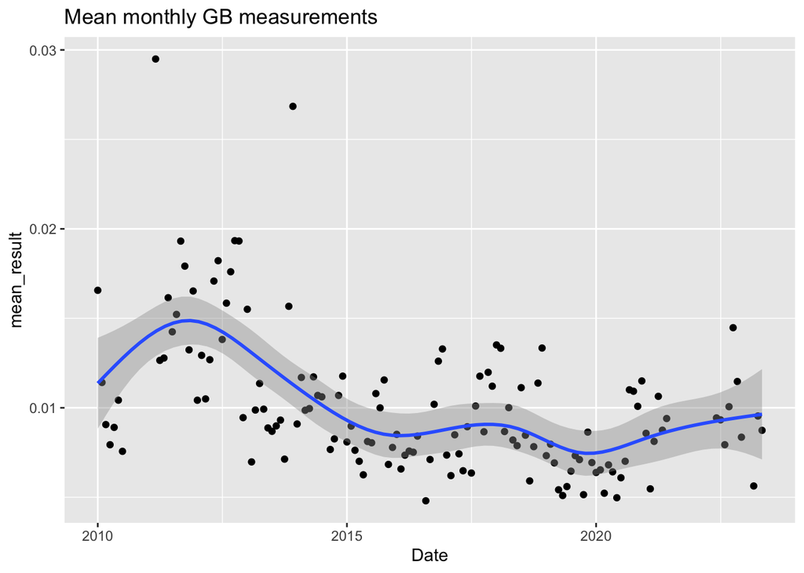

```r
GB_monthly_forplot <- GB_monthly %>% mutate(Date2 = as.Date(paste0(Date, '-01')))

ggplot(GB_monthly_forplot, aes(Date2, mean_result)) +
  geom_point() +
  geom_smooth(method = "gam") +
  labs(title = "Mean monthly GB measurements", x = "Date")
```

## Merging flaring data

```r
pb_vnf <- readRDS('./pb_vnf/pb-vnf.rds')
```

```r
# Only keep 1600K and above for temp_bb, 400k observations -> 391k
pb_vnf <- pb_vnf %>% filter(temp_bb >= 1600)
```

```r
# lon, lat of Carlsbad monitor:  (32.3840, -104.2640)
carlsbad_lonlat <- c(-104.2640, 32.3840)
distance_km <- function(long, lati){
  start <- c(long, lati)
  distGeo(start, carlsbad_lonlat) / 1000
}
```

```r
pb_vnf_distance <- pb_vnf %>%
  mutate(distToCarls = mapply(distance_km, lon, lat)) %>%
  select(c("vnf_id", "date", "distToCarls", "temp_bb", "rhi", "area_bb", "lon", "lat"))
```

## Exploring the distance to Carlsbad station

```r
pb_vnf_distance <- pb_vnf_distance %>%
  mutate(dist_cat = case_when(distToCarls < 1 ~ "<1km",
                              distToCarls >= 1 & distToCarls < 5 ~ "1~5km",
                              distToCarls >= 5 & distToCarls < 10 ~ "5~10km",
                              TRUE ~ ">=10km"))
```

```r
pb_vnf_distance %>%
  group_by(dist_cat) %>%
  summarize(count = n())
```

```
## # A tibble: 3 × 2
##   dist_cat  count
##   <chr>     <int>
## 1 1~5km        58
## 2 5~10km      703
## 3 >=10km   391057
```

```r
pb_vnf_distance <- pb_vnf_distance %>% filter(dist_cat != ">=10km")
```

## Exporing relative locations

```r
library(leaflet)
library(leaflet.extras)
```

```r
leaflet() %>%
  addProviderTiles("Esri.WorldImagery") %>%
  addProviderTiles("CartoDB.PositronOnlyLabels") %>%
  addCircleMarkers(data=data.frame(lng=-104.2640, lat=32.3840),lng=~lng,lat=~lat,
                   radius=7,fillColor=~'black',fillOpacity = 0.99, weight = 1,
                   col='white',stroke = T, group = 'RadNet Monitor') %>%
  addCircleMarkers(data=pb_vnf_distance, lng=~lon, lat=~lat,
                   stroke = T, fillColor = ~case_when(dist_cat == "<1km" ~ "red",
                                                      dist_cat == "1~5km" ~ "orange",
                                                      dist_cat == "5~10km" ~ "yellow",

                   ), radius = 2, weight = 1,
                   group = 'Flares', col='white', fillOpacity = 0.7) %>%
  addLegend(colors = c('red', 'orange', 'yellow', 'black'),
            labels = c('<1km','1~5km','5~10km', 'RadNet monitor'),
            position = 'bottomleft')
```

[interactive chart not shown]

## Connecting to radioactivity measurement

```r
head(GB_monthly)
```

```
## # A tibble: 6 × 2
##   Date    mean_result
##   <chr>         <dbl>
## 1 2010-01     0.0166
## 2 2010-02     0.0114
## 3 2010-03     0.00906
## 4 2010-04     0.00793
## 5 2010-05     0.00890
## 6 2010-06     0.0104
```

```r
pb_vnf_monthly <- pb_vnf_distance %>% mutate(date = substr(date, 1, 7)) %>% group_by(date) %>%
  summarize(count = n())
```

```r
seq_dates <- data.frame(date = seq.Date(from = as.Date("2014-09-01"),
                           to = as.Date("2022-07-01"),
                           by = "month"))
seq_dates <- seq_dates %>% mutate(date = substr(date, 1, 7))
```

```r
pb_vnf_merge <- merge(x = pb_vnf_monthly,
                        y = seq_dates,
                        by.x = "date",
                        by.y = "date",
                        all.x = TRUE,
                        all.y = TRUE)
pb_vnf_merge <- pb_vnf_merge %>% mutate(count = if_else(is.na(count), 0, count))
```

```r
GB_monthly <- GB_monthly %>% filter(Date >= "2014-09" & Date <= "2022-07")
pb_vnf_merge <- pb_vnf_merge %>% filter(date %in% GB_monthly$Date)
pb_vnf_merge <- merge(x = pb_vnf_merge,
                        y = GB_monthly,
                        by.x = "date",
                        by.y = "Date",
                        all.x = TRUE,
                        all.y = TRUE)
pb_vnf_merge <- pb_vnf_merge %>% mutate(unix_time = as.numeric(as.POSIXct(paste0(date, "-01"), format="%Y-%m-%d")))
```

```r
pb_vnf_monthly <- pb_vnf_distance %>% mutate(month = substr(date, 1, 7))
pb_vnf_monthly <- merge(x = pb_vnf_monthly,
                        y = GB_monthly,
                        by.x = "month",
                        by.y = "Date",
                        all.x = TRUE,
                        all.y = FALSE)
```

# Modeling

```r
glm0 <- glm(mean_result ~ 1, data = pb_vnf_merge)
summary(glm0)
```

```
##
## Call:
## glm(formula = mean_result ~ 1, data = pb_vnf_merge)
##
## Deviance Residuals:
##        Min          1Q      Median          3Q         Max
## -0.0036392  -0.0015644  -0.0003519   0.0016029   0.0050715
##
## Coefficients:
##              Estimate Std. Error t value Pr(>|t|)
## (Intercept) 0.0084419  0.0002417   34.92   <2e-16 ***
## ---
## Signif. codes:  0 '***' 0.001 '**' 0.01 '*' 0.05 '.' 0.1 ' ' 1
##
## (Dispersion parameter for gaussian family taken to be 4.850586e-06)
##
##     Null deviance: 0.00039775  on 82  degrees of freedom
## Residual deviance: 0.00039775  on 82  degrees of freedom
## AIC: -777.08
##
## Number of Fisher Scoring iterations: 2
```

```r
glm1 <- glm(mean_result ~ count, data = pb_vnf_merge)
summary(glm1)
```

```
##
## Call:
## glm(formula = mean_result ~ count, data = pb_vnf_merge)
##
## Deviance Residuals:
##       Min         1Q     Median         3Q        Max
## -0.004066  -0.001397  -0.000451   0.001475   0.004985
##
## Coefficients:
##               Estimate Std. Error t value Pr(>|t|)
## (Intercept)  8.869e-03  2.688e-04  32.999  < 2e-16 ***
## count       -4.869e-05  1.582e-05  -3.077  0.00285 **
## ---
## Signif. codes:  0 '***' 0.001 '**' 0.01 '*' 0.05 '.' 0.1 ' ' 1
##
## (Dispersion parameter for gaussian family taken to be 4.396564e-06)
##
##     Null deviance: 0.00039775  on 82  degrees of freedom
## Residual deviance: 0.00035612  on 81  degrees of freedom
## AIC: -784.26
##
## Number of Fisher Scoring iterations: 2
```

```r
lm1 <- lm(mean_result ~ count, data = pb_vnf_merge)
summary(lm1)
```

```
##
## Call:
## lm(formula = mean_result ~ count, data = pb_vnf_merge)
##
## Residuals:
##       Min        1Q    Median        3Q       Max
## -0.004066 -0.001397 -0.000451  0.001475  0.004985
##
## Coefficients:
##               Estimate Std. Error t value Pr(>|t|)
## (Intercept)  8.869e-03  2.688e-04  32.999  < 2e-16 ***
## count       -4.869e-05  1.582e-05  -3.077  0.00285 **
## ---
## Signif. codes:  0 '***' 0.001 '**' 0.01 '*' 0.05 '.' 0.1 ' ' 1
##
## Residual standard error: 0.002097 on 81 degrees of freedom
## Multiple R-squared:  0.1047, Adjusted R-squared:  0.0936
## F-statistic: 9.468 on 1 and 81 DF,  p-value: 0.002852
```

```r
glm2 <- glm(mean_result ~ temp_bb + rhi + area_bb + distToCarls, data = pb_vnf_monthly, na.action = "na.exclude")
summary(glm2)
```

```
##
## Call:
## glm(formula = mean_result ~ temp_bb + rhi + area_bb + distToCarls,
##     data = pb_vnf_monthly, na.action = "na.exclude")
##
## Deviance Residuals:
##        Min          1Q      Median          3Q         Max
## -0.0029597  -0.0016021  -0.0004578   0.0009916   0.0062602
##
## Coefficients:
##               Estimate Std. Error t value Pr(>|t|)
## (Intercept)  3.754e-03  1.122e-03   3.345 0.000865 ***
## temp_bb      1.511e-06  5.336e-07   2.831 0.004770 **
## rhi         -1.186e-04  8.467e-05  -1.401 0.161569
## area_bb      7.739e-05  4.609e-05   1.679 0.093562 .
## distToCarls  7.666e-05  4.865e-05   1.576 0.115507
## ---
## Signif. codes:  0 '***' 0.001 '**' 0.01 '*' 0.05 '.' 0.1 ' ' 1
##
## (Dispersion parameter for gaussian family taken to be 4.068562e-06)
##
##     Null deviance: 0.0029904  on 727  degrees of freedom
## Residual deviance: 0.0029416  on 723  degrees of freedom
##   (33 observations deleted due to missingness)
## AIC: -6963.1
##
## Number of Fisher Scoring iterations: 2
```

```r
glm3 <- glm(mean_result ~ temp_bb + rhi + area_bb + distToCarls + splines::bs(as.numeric(as.POSIXct(date)), df = 6), data = pb_vnf_monthly, na.action = "na.exclude")
summary(glm3)
```

```
##
## Call:
## glm(formula = mean_result ~ temp_bb + rhi + area_bb + distToCarls +
##     splines::bs(as.numeric(as.POSIXct(date)), df = 6), data = pb_vnf_monthly,
##     na.action = "na.exclude")
##
## Deviance Residuals:
##        Min          1Q      Median          3Q         Max
## -0.0054447  -0.0011518  -0.0000009   0.0009495   0.0061032
##
## Coefficients:
##                                                      Estimate Std. Error
## (Intercept)                                         5.066e-03  1.074e-03
## temp_bb                                             1.425e-06  4.121e-07
## rhi                                                 4.340e-06  6.551e-05
## area_bb                                             1.043e-04  3.538e-05
## distToCarls                                        -4.680e-05  3.951e-05
## splines::bs(as.numeric(as.POSIXct(date)), df = 6)1  6.021e-03  1.533e-03
## splines::bs(as.numeric(as.POSIXct(date)), df = 6)2  2.242e-03  8.570e-04
## splines::bs(as.numeric(as.POSIXct(date)), df = 6)3 -1.867e-03  6.976e-04
## splines::bs(as.numeric(as.POSIXct(date)), df = 6)4  1.820e-04  8.425e-04
## splines::bs(as.numeric(as.POSIXct(date)), df = 6)5  8.704e-03  1.609e-03
## splines::bs(as.numeric(as.POSIXct(date)), df = 6)6  1.072e-03  8.351e-04
##                                                    t value Pr(>|t|)
## (Intercept)                                          4.718 2.87e-06 ***
## temp_bb                                              3.459 0.000575 ***
## rhi                                                  0.066 0.947197
## area_bb                                              2.949 0.003289 **
## distToCarls                                         -1.184 0.236631
## splines::bs(as.numeric(as.POSIXct(date)), df = 6)1   3.927 9.43e-05 ***
## splines::bs(as.numeric(as.POSIXct(date)), df = 6)2   2.617 0.009069 **
## splines::bs(as.numeric(as.POSIXct(date)), df = 6)3  -2.676 0.007626 **
## splines::bs(as.numeric(as.POSIXct(date)), df = 6)4   0.216 0.829072
## splines::bs(as.numeric(as.POSIXct(date)), df = 6)5   5.411 8.57e-08 ***
## splines::bs(as.numeric(as.POSIXct(date)), df = 6)6   1.284 0.199589
## ---
## Signif. codes:  0 '***' 0.001 '**' 0.01 '*' 0.05 '.' 0.1 ' ' 1
##
## (Dispersion parameter for gaussian family taken to be 2.379916e-06)
##
##     Null deviance: 0.0029904  on 727  degrees of freedom
## Residual deviance: 0.0017064  on 717  degrees of freedom
##   (33 observations deleted due to missingness)
## AIC: -7347.6
##
## Number of Fisher Scoring iterations: 2
```

```r
lm2 <- lm(mean_result ~ temp_bb + rhi + area_bb + distToCarls + as.numeric(as.POSIXct(date)), data = pb_vnf_monthly, na.action = "na.exclude")
summary(lm2)
```

```
##
## Call:
## lm(formula = mean_result ~ temp_bb + rhi + area_bb + distToCarls +
##     as.numeric(as.POSIXct(date)), data = pb_vnf_monthly, na.action = "na.exclude")
##
## Residuals:
##        Min         1Q     Median         3Q        Max
## -0.0028982 -0.0016199 -0.0004073  0.0007843  0.0058322
##
## Coefficients:
##                                Estimate Std. Error t value Pr(>|t|)
## (Intercept)                   1.773e-02  3.922e-03   4.521  7.2e-06 ***
## temp_bb                       1.628e-06  5.299e-07   3.072 0.002206 **
## rhi                          -1.172e-04  8.393e-05  -1.396 0.163031
## area_bb                       7.610e-05  4.569e-05   1.666 0.096239 .
## distToCarls                   3.301e-05  4.963e-05   0.665 0.506223
## as.numeric(as.POSIXct(date)) -8.838e-12  2.378e-12  -3.716 0.000218 ***
## ---
## Signif. codes:  0 '***' 0.001 '**' 0.01 '*' 0.05 '.' 0.1 ' ' 1
##
## Residual standard error: 0.001999 on 722 degrees of freedom
##   (33 observations deleted due to missingness)
## Multiple R-squared:  0.0348, Adjusted R-squared:  0.02811
## F-statistic: 5.206 on 5 and 722 DF,  p-value: 0.0001056
```

# Weather data

```r
weather <- read_rds("./NMED_monitor/data/pol_data.rds")
```

```r
weatherex <- weather %>%
  mutate(date = as.Date(substr(date, 1, 10)))
```

```r
# helper method for finding mode
Mode <- function(x) {
  ux <- unique(x)
  ux[which.max(tabulate(match(x, ux)))]
}
```

```r
weather_daily <- weatherex %>%
  group_by(date) %>%
  summarise(mean_solar = mean(`Solar Rad`),
            mean_temp = mean(Temp_2m),
            mean_ws = mean(ws),
            oil = mean(oil),
            gas = mean(gas),
            o3 = mean(o3),
            PM25 = mean(PM25),
            nox = mean(nox),
            season = Mode(season),
            # add most frequent wind direction
            most_wind_direction = Mode(wd_sec))
```

```r
pb_vnf_weather <- merge(x = pb_vnf_monthly,
                        y = weather_daily,
                        by.x = "date",
                        by.y = "date",
                        all.x = FALSE,
                        all.y = FALSE)
```

```r
glm4 <- glm(mean_result ~ temp_bb +
              rhi +
              area_bb +
              distToCarls +
              splines::bs(as.numeric(as.POSIXct(date)) , df = 6) +
              mean_solar +
              mean_temp +
              mean_ws +
              oil + gas, data = pb_vnf_weather, na.action = "na.exclude")
summary(glm4)
```

```
##
## Call:
## glm(formula = mean_result ~ temp_bb + rhi + area_bb + distToCarls +
##     splines::bs(as.numeric(as.POSIXct(date)), df = 6) + mean_solar +
##     mean_temp + mean_ws + oil + gas, data = pb_vnf_weather, na.action = "na.exclude")
##
## Deviance Residuals:
##        Min          1Q      Median          3Q         Max
## -0.0079382  -0.0008434  -0.0000552   0.0008324   0.0045713
##
## Coefficients:
##                                                      Estimate Std. Error
## (Intercept)                                         9.229e-03  1.175e-03
## temp_bb                                             7.026e-07  4.495e-07
## rhi                                                 3.019e-05  6.762e-05
## area_bb                                             5.399e-05  3.521e-05
## distToCarls                                         4.308e-05  4.138e-05
## splines::bs(as.numeric(as.POSIXct(date)), df = 6)1 -1.203e-03  1.659e-03
## splines::bs(as.numeric(as.POSIXct(date)), df = 6)2  6.024e-03  9.982e-04
## splines::bs(as.numeric(as.POSIXct(date)), df = 6)3  1.261e-03  1.512e-03
## splines::bs(as.numeric(as.POSIXct(date)), df = 6)4  3.528e-03  2.037e-03
## splines::bs(as.numeric(as.POSIXct(date)), df = 6)5  1.321e-02  1.843e-03
## splines::bs(as.numeric(as.POSIXct(date)), df = 6)6  7.404e-03  2.328e-03
## mean_solar                                         -8.616e-06  1.306e-06
## mean_temp                                          -2.371e-06  1.023e-05
## mean_ws                                            -4.014e-05  5.124e-05
## oil                                                 1.104e-09  4.283e-10
## gas                                                -5.128e-10  1.410e-10
##                                                    t value Pr(>|t|)
## (Intercept)                                          7.851 2.53e-14 ***
## temp_bb                                              1.563 0.118703
## rhi                                                  0.446 0.655461
## area_bb                                              1.534 0.125766
## distToCarls                                          1.041 0.298338
## splines::bs(as.numeric(as.POSIXct(date)), df = 6)1  -0.725 0.468833
## splines::bs(as.numeric(as.POSIXct(date)), df = 6)2   6.035 3.10e-09 ***
## splines::bs(as.numeric(as.POSIXct(date)), df = 6)3   0.833 0.404979
## splines::bs(as.numeric(as.POSIXct(date)), df = 6)4   1.732 0.083932 .
## splines::bs(as.numeric(as.POSIXct(date)), df = 6)5   7.165 2.80e-12 ***
## splines::bs(as.numeric(as.POSIXct(date)), df = 6)6   3.181 0.001561 **
## mean_solar                                          -6.595 1.08e-10 ***
## mean_temp                                           -0.232 0.816749
## mean_ws                                             -0.783 0.433786
## oil                                                  2.578 0.010226 *
## gas                                                 -3.637 0.000305 ***
## ---
## Signif. codes:  0 '***' 0.001 '**' 0.01 '*' 0.05 '.' 0.1 ' ' 1
##
## (Dispersion parameter for gaussian family taken to be 2.028666e-06)
##
##     Null deviance: 0.0021380  on 515  degrees of freedom
## Residual deviance: 0.0010143  on 500  degrees of freedom
##   (245 observations deleted due to missingness)
## AIC: -5281.7
##
## Number of Fisher Scoring iterations: 2
```

```r
lm4 <- lm(mean_result ~ temp_bb +
              rhi +
              area_bb +
              distToCarls +
              as.numeric(as.POSIXct(date)) +
              mean_solar +
              mean_temp +
              mean_ws +
              oil + gas, data = pb_vnf_weather, na.action = "na.exclude")
summary(lm4)
```

```
##
## Call:
## lm(formula = mean_result ~ temp_bb + rhi + area_bb + distToCarls +
##     as.numeric(as.POSIXct(date)) + mean_solar + mean_temp + mean_ws +
##     oil + gas, data = pb_vnf_weather, na.action = "na.exclude")
##
## Residuals:
##        Min         1Q     Median         3Q        Max
## -0.0084794 -0.0009986 -0.0001303  0.0011439  0.0047770
##
## Coefficients:
##                                Estimate Std. Error t value Pr(>|t|)
## (Intercept)                  -9.609e-02  1.003e-02  -9.580  < 2e-16 ***
## temp_bb                       5.020e-07  4.939e-07   1.016   0.3099
## rhi                          -2.237e-05  7.392e-05  -0.303   0.7623
## area_bb                       5.593e-05  3.874e-05   1.444   0.1494
## distToCarls                   8.921e-05  4.337e-05   2.057   0.0402 *
## as.numeric(as.POSIXct(date))  7.419e-11  6.939e-12  10.691  < 2e-16 ***
## mean_solar                   -7.408e-06  1.381e-06  -5.363 1.25e-07 ***
## mean_temp                     3.269e-06  1.085e-05   0.301   0.7634
## mean_ws                       1.820e-06  5.434e-05   0.033   0.9733
## oil                          -8.697e-10  3.956e-10  -2.199   0.0284 *
## gas                          -6.844e-10  1.285e-10  -5.327 1.51e-07 ***
## ---
## Signif. codes:  0 '***' 0.001 '**' 0.01 '*' 0.05 '.' 0.1 ' ' 1
##
## Residual standard error: 0.001574 on 505 degrees of freedom
##   (245 observations deleted due to missingness)
## Multiple R-squared:  0.415,  Adjusted R-squared:  0.4034
## F-statistic: 35.82 on 10 and 505 DF,  p-value: < 2.2e-16
```

# Adding wind direction and counts

```r
# getting counts for number of vnf in month/day
vnf_month_counts <- pb_vnf_monthly %>% group_by(month) %>% summarize(month_count = n())
vnf_day_counts <- pb_vnf_monthly %>% group_by(date) %>% summarize(day_count = n())
```

```r
pb_vnf_complete <- merge(x = pb_vnf_weather,
                         y = vnf_month_counts,
                         by.x = "month",
                         by.y = "month",
                         all.x = TRUE,
                         all.y = TRUE)
pb_vnf_complete <- merge(x = pb_vnf_complete,
                         y = vnf_day_counts,
                         by.x = "date",
                         by.y = "date",
                         all.x = TRUE,
                         all.y = TRUE)
```

```r
# modeling
lm_complete <- lm(mean_result ~ temp_bb +
                    rhi +
                    area_bb +
                    distToCarls +
                    as.numeric(as.POSIXct(date)) +
                    mean_solar +
                    mean_temp +
                    mean_ws +
                    oil + gas +
                    most_wind_direction +
                    month_count +
                    day_count, data = pb_vnf_complete, na.action = "na.omit")
summary(lm_complete)
```

```
##
## Call:
## lm(formula = mean_result ~ temp_bb + rhi + area_bb + distToCarls +
##     as.numeric(as.POSIXct(date)) + mean_solar + mean_temp + mean_ws +
##     oil + gas + most_wind_direction + month_count + day_count,
##     data = pb_vnf_complete, na.action = "na.omit")
##
## Residuals:
##        Min         1Q     Median         3Q        Max
## -0.0083129 -0.0009930 -0.0001717  0.0010613  0.0037327
##
## Coefficients:
##                                Estimate Std. Error t value Pr(>|t|)
## (Intercept)                  -5.381e-02  1.139e-02  -4.723 3.02e-06 ***
## temp_bb                       5.970e-07  4.743e-07   1.259  0.20877
## rhi                          -3.457e-05  7.294e-05  -0.474  0.63575
## area_bb                       8.868e-05  3.776e-05   2.348  0.01925 *
## distToCarls                   5.773e-05  4.181e-05   1.381  0.16794
## as.numeric(as.POSIXct(date))  4.473e-11  7.869e-12   5.684 2.24e-08 ***
## mean_solar                   -1.019e-05  1.404e-06  -7.260 1.49e-12 ***
## mean_temp                    -1.703e-05  1.115e-05  -1.527  0.12731
## mean_ws                      -2.966e-05  5.706e-05  -0.520  0.60336
## oil                          -6.429e-10  3.799e-10  -1.692  0.09118 .
## gas                          -3.472e-10  1.326e-10  -2.618  0.00912 **
## most_wind_directionQ2         4.328e-04  3.990e-04   1.085  0.27848
## most_wind_directionQ3         4.270e-04  4.073e-04   1.048  0.29496
## most_wind_directionQ4         9.461e-04  4.246e-04   2.228  0.02633 *
## month_count                  -3.921e-05  6.308e-06  -6.216 1.08e-09 ***
## day_count                    -6.088e-05  5.457e-05  -1.115  0.26518
## ---
## Signif. codes:  0 '***' 0.001 '**' 0.01 '*' 0.05 '.' 0.1 ' ' 1
##
## Residual standard error: 0.001502 on 500 degrees of freedom
##   (245 observations deleted due to missingness)
## Multiple R-squared:  0.4723, Adjusted R-squared:  0.4565
## F-statistic: 29.84 on 15 and 500 DF,  p-value: < 2.2e-16
```

```r
# lot of missingness in the weather data
colSums(is.na(pb_vnf_complete))
```

```
##                date               month              vnf_id         distToCarls
##                   0                   0                   0                   0
##             temp_bb                 rhi             area_bb                 lon
##                   0                   0                   0                   0
##                 lat            dist_cat         mean_result          mean_solar
##                   0                   0                  33                 213
##           mean_temp             mean_ws                 oil                 gas
##                 179                 179                   0                   0
##                  o3                PM25                 nox              season
##                 203                 757                 215                   0
## most_wind_direction         month_count           day_count
##                 119                   0                   0
```

```r
# fit one more without those weather variables
lm_noweather <- lm(mean_result ~ temp_bb +
                    rhi +
                    area_bb +
                    distToCarls +
                    as.numeric(as.POSIXct(date)) +
                    oil + gas +
                    month_count +
                    day_count, data = pb_vnf_complete %>% select(-c("mean_temp", "mean_ws", "most_wind_direction", "mean_solar")), na.action = "na.omit")
summary(lm_noweather)
```

```
##
## Call:
## lm(formula = mean_result ~ temp_bb + rhi + area_bb + distToCarls +
##     as.numeric(as.POSIXct(date)) + oil + gas + month_count +
##     day_count, data = pb_vnf_complete %>% select(-c("mean_temp",
##     "mean_ws", "most_wind_direction", "mean_solar")), na.action = "na.omit")
##
## Residuals:
##        Min         1Q     Median         3Q        Max
## -0.0048889 -0.0011569 -0.0002792  0.0013159  0.0048376
##
## Coefficients:
##                                Estimate Std. Error t value Pr(>|t|)
## (Intercept)                  -3.176e-02  1.027e-02  -3.091 0.002070 **
## temp_bb                       1.649e-06  4.615e-07   3.574 0.000376 ***
## rhi                          -4.172e-05  7.483e-05  -0.558 0.577276
## area_bb                       1.166e-04  4.042e-05   2.886 0.004024 **
## distToCarls                   3.874e-06  4.321e-05   0.090 0.928582
## as.numeric(as.POSIXct(date))  2.632e-11  7.061e-12   3.728 0.000208 ***
## oil                           9.413e-10  3.856e-10   2.441 0.014888 *
## gas                          -4.749e-10  1.300e-10  -3.653 0.000278 ***
## month_count                  -5.146e-05  4.209e-06 -12.227  < 2e-16 ***
## day_count                     7.090e-05  5.155e-05   1.375 0.169446
## ---
## Signif. codes:  0 '***' 0.001 '**' 0.01 '*' 0.05 '.' 0.1 ' ' 1
##
## Residual standard error: 0.00173 on 718 degrees of freedom
##   (33 observations deleted due to missingness)
## Multiple R-squared:  0.2813, Adjusted R-squared:  0.2723
## F-statistic: 31.22 on 9 and 718 DF,  p-value: < 2.2e-16
```

```r
lm_complete2 <- lm(mean_result ~ temp_bb +
                    area_bb +
                    distToCarls +
                    as.numeric(as.POSIXct(date)) +
                    oil + gas +
                    mean_solar +
                    month_count +
                    day_count, data = pb_vnf_complete, na.action = "na.omit")
summary(lm_complete2)
```

```
##
## Call:
## lm(formula = mean_result ~ temp_bb + area_bb + distToCarls +
##     as.numeric(as.POSIXct(date)) + oil + gas + mean_solar + month_count +
##     day_count, data = pb_vnf_complete, na.action = "na.omit")
##
## Residuals:
##        Min         1Q     Median         3Q        Max
## -0.0085282 -0.0009859 -0.0001702  0.0011140  0.0038402
##
## Coefficients:
##                                Estimate Std. Error t value Pr(>|t|)
## (Intercept)                  -6.040e-02  1.108e-02  -5.450 7.87e-08 ***
## temp_bb                       5.300e-07  4.741e-07   1.118 0.264175
## area_bb                       7.064e-05  1.944e-05   3.633 0.000308 ***
## distToCarls                   6.477e-05  4.193e-05   1.544 0.123111
## as.numeric(as.POSIXct(date))  4.971e-11  7.645e-12   6.503 1.90e-10 ***
## oil                          -5.430e-10  3.685e-10  -1.473 0.141264
## gas                          -4.252e-10  1.259e-10  -3.376 0.000791 ***
## mean_solar                   -1.158e-05  1.159e-06  -9.986  < 2e-16 ***
## month_count                  -3.558e-05  6.119e-06  -5.815 1.08e-08 ***
## day_count                    -6.048e-05  5.118e-05  -1.182 0.237919
## ---
## Signif. codes:  0 '***' 0.001 '**' 0.01 '*' 0.05 '.' 0.1 ' ' 1
##
## Residual standard error: 0.001512 on 506 degrees of freedom
##   (245 observations deleted due to missingness)
## Multiple R-squared:  0.4593, Adjusted R-squared:  0.4497
## F-statistic: 47.75 on 9 and 506 DF,  p-value: < 2.2e-16
```

```r
vif(lm_complete)
```

```
##                                   GVIF Df GVIF^(1/(2*Df))
## temp_bb                       1.197212  1        1.094172
## rhi                           4.932305  1        2.220879
## area_bb                       5.013528  1        2.239091
## distToCarls                   1.083719  1        1.041018
## as.numeric(as.POSIXct(date)) 18.451492  1        4.295520
## mean_solar                    2.439650  1        1.561938
## mean_temp                     2.671030  1        1.634329
## mean_ws                       1.275522  1        1.129390
## oil                          20.418253  1        4.518656
## gas                          55.136114  1        7.425370
## most_wind_direction           1.531001  3        1.073567
## month_count                   3.815814  1        1.953411
## day_count                     1.656585  1        1.287084
```

```r
vif(lm_complete2)
```

```
##                      temp_bb                      area_bb
##                     1.181219                     1.312496
##                  distToCarls as.numeric(as.POSIXct(date))
##                     1.076730                    17.194548
##                          oil                          gas
##                    18.976610                    49.102520
##                   mean_solar                  month_count
##                     1.643301                     3.545787
##                    day_count
##                     1.438796
```

# Gam models

```r
gam_complete <- gam(mean_result ~ temp_bb +
                    rhi +
                    area_bb +
                    distToCarls +
                    as.numeric(as.POSIXct(date)) +
                    mean_solar +
                    mean_temp +
                    mean_ws +
                    oil + gas +
                    most_wind_direction +
                    month_count +
                    day_count, data = pb_vnf_complete)
summary(gam_complete)
```

```
##
## Family: gaussian
## Link function: identity
##
## Formula:
## mean_result ~ temp_bb + rhi + area_bb + distToCarls + as.numeric(as.POSIXct(date)) +
##     mean_solar + mean_temp + mean_ws + oil + gas + most_wind_direction +
##     month_count + day_count
##
## Parametric coefficients:
##                                Estimate Std. Error t value Pr(>|t|)
## (Intercept)                   2.459e-11  4.132e-12   5.952 4.93e-09 ***
## temp_bb                      -2.057e-07  4.989e-07  -0.412     0.68
## rhi                           1.048e-08  2.572e-09   4.076 5.32e-05 ***
## area_bb                       2.722e-08  6.158e-09   4.420 1.21e-05 ***
## distToCarls                  -8.744e-09  1.370e-09  -6.381 3.95e-10 ***
## as.numeric(as.POSIXct(date))  8.769e-12  7.153e-13  12.260  < 2e-16 ***
## mean_solar                   -6.528e-06  1.022e-06  -6.390 3.73e-10 ***
## mean_temp                    -6.029e-07  9.437e-08  -6.388 3.77e-10 ***
## mean_ws                      -1.421e-08  2.248e-09  -6.322 5.62e-10 ***
## oil                          -2.776e-09  3.343e-10  -8.302 9.18e-16 ***
## gas                           2.889e-10  7.157e-11   4.036 6.28e-05 ***
## most_wind_directionQ2        -1.175e-08  1.842e-09  -6.380 3.97e-10 ***
## most_wind_directionQ3         7.139e-09  1.117e-09   6.389 3.76e-10 ***
## most_wind_directionQ4         3.286e-09  5.197e-10   6.322 5.62e-10 ***
## month_count                   8.115e-07  1.270e-07   6.388 3.77e-10 ***
## day_count                     4.728e-08  7.398e-09   6.391 3.72e-10 ***
## ---
## Signif. codes:  0 '***' 0.001 '**' 0.01 '*' 0.05 '.' 0.1 ' ' 1
##
##
## Rank: 5/16
## R-sq.(adj) =  0.296   Deviance explained = 30.1%
## GCV = 2.9521e-06  Scale est. = 2.9235e-06  n = 516
```

```r
# Smooth on oil and gas

gam_v2 <- gam(mean_result ~ temp_bb +
                    rhi +
                    area_bb +
                    distToCarls +
                    as.numeric(as.POSIXct(date)) +
                    mean_solar +
                    mean_temp +
                    mean_ws +
                    s(oil, bs = "cr") +
                    s(gas, bs ="cr") +
                    most_wind_direction +
                    month_count +
                    day_count, data = pb_vnf_complete)
summary(gam_v2)
```

```
##
## Family: gaussian
## Link function: identity
##
## Formula:
## mean_result ~ temp_bb + rhi + area_bb + distToCarls + as.numeric(as.POSIXct(date)) +
##     mean_solar + mean_temp + mean_ws + s(oil, bs = "cr") + s(gas,
##     bs = "cr") + most_wind_direction + month_count + day_count
##
## Parametric coefficients:
##                                Estimate Std. Error t value Pr(>|t|)
## (Intercept)                   1.190e-10  2.415e-11   4.926 1.13e-06 ***
## temp_bb                       1.488e-06  5.761e-07   2.582 0.010093 *
## rhi                           7.320e-09  4.113e-09   1.780 0.075687 .
## area_bb                       1.737e-08  9.346e-09   1.858 0.063690 .
## distToCarls                  -4.954e-09  1.420e-09  -3.488 0.000529 ***
## as.numeric(as.POSIXct(date))  3.717e-12  7.304e-13   5.089 5.06e-07 ***
## mean_solar                   -4.943e-06  1.192e-06  -4.147 3.94e-05 ***
## mean_temp                    -4.734e-07  1.152e-07  -4.110 4.61e-05 ***
## mean_ws                      -9.017e-09  2.531e-09  -3.563 0.000400 ***
## most_wind_directionQ2        -9.290e-09  2.277e-09  -4.079 5.24e-05 ***
## most_wind_directionQ3         6.300e-09  1.477e-09   4.267 2.36e-05 ***
## most_wind_directionQ4         2.145e-09  5.492e-10   3.906 0.000106 ***
## month_count                   6.775e-07  1.719e-07   3.942 9.20e-05 ***
## day_count                     3.871e-08  9.461e-09   4.091 4.98e-05 ***
## ---
## Signif. codes:  0 '***' 0.001 '**' 0.01 '*' 0.05 '.' 0.1 ' ' 1
##
## Approximate significance of smooth terms:
##              edf    Ref.df       F  p-value
## s(oil) 1.981e-06 1.981e-06 7281380 0.000164 ***
## s(gas) 1.145e-04 1.145e-04  152695 3.47e-05 ***
## ---
## Signif. codes:  0 '***' 0.001 '**' 0.01 '*' 0.05 '.' 0.1 ' ' 1
##
## Rank: 3/32
## R-sq.(adj) =  0.00495   Deviance explained = 0.878%
## GCV = 4.1551e-06  Scale est. = 4.131e-06  n = 516
```

```r
# Standardizing dataframe
pb_vnf_pre <- pb_vnf_complete %>% mutate(date = as.numeric(as.POSIXct(date)))
preprocessParams <- preProcess(pb_vnf_pre %>% select(mean_result, temp_bb, mean_solar, mean_temp, mean_ws, rhi, area_bb, oil, gas, distToCarls, date, month_count, day_count), method=c("range"))
```

```r
print(preprocessParams)
```

```
## Created from 516 samples and 13 variables
##
## Pre-processing:
##   - ignored (0)
##   - re-scaling to [0, 1] (13)
```

```r
transformed <- predict(preprocessParams, pb_vnf_pre %>% select(mean_result, temp_bb, mean_solar, mean_temp, mean_ws, rhi, area_bb, oil, gas, distToCarls, date, month_count, day_count))
```

```r
# fitting the scaled model
gam_v3 <- gam(mean_result ~ date + temp_bb + mean_solar + mean_temp + mean_ws + rhi + area_bb + oil + gas + distToCarls + month_count + day_count, data=transformed)
summary(gam_v3)
```

```
##
## Family: gaussian
## Link function: identity
##
## Formula:
## mean_result ~ date + temp_bb + mean_solar + mean_temp + mean_ws +
##     rhi + area_bb + oil + gas + distToCarls + month_count + day_count
##
## Parametric coefficients:
##             Estimate Std. Error t value Pr(>|t|)
## (Intercept)  0.56962    0.07694   7.403 5.63e-13 ***
## date         1.34116    0.22964   5.840 9.36e-09 ***
## temp_bb      0.05910    0.04824   1.225  0.22109
## mean_solar  -0.45357    0.06224  -7.288 1.23e-12 ***
## mean_temp   -0.09986    0.05340  -1.870  0.06204 .
## mean_ws     -0.01861    0.06688  -0.278  0.78095
## rhi         -0.02400    0.13300  -0.180  0.85685
## area_bb      0.20671    0.10000   2.067  0.03924 *
## oil         -0.32189    0.17603  -1.829  0.06805 .
## gas         -0.85117    0.32416  -2.626  0.00891 **
## distToCarls  0.05295    0.03692   1.434  0.15220
## month_count -0.27361    0.04523  -6.049 2.84e-09 ***
## day_count   -0.05948    0.03767  -1.579  0.11495
## ---
## Signif. codes:  0 '***' 0.001 '**' 0.01 '*' 0.05 '.' 0.1 ' ' 1
##
##
## R-sq.(adj) =   0.45   Deviance explained = 46.3%
## GCV = 0.03209  Scale est. = 0.031281  n = 516
```

```r
# smaller model with normalization and smoothing
gam_v4 <- gam(mean_result ~ s(date, bs="cr") + temp_bb + mean_solar + mean_temp + area_bb + s(oil, bs="cr") + s(gas, bs="cr") + distToCarls + month_count + day_count, data=transformed)
summary(gam_v4)
```

```
##
## Family: gaussian
## Link function: identity
##
## Formula:
## mean_result ~ s(date, bs = "cr") + temp_bb + mean_solar + mean_temp +
##     area_bb + s(oil, bs = "cr") + s(gas, bs = "cr") + distToCarls +
##     month_count + day_count
##
## Parametric coefficients:
##              Estimate Std. Error t value Pr(>|t|)
## (Intercept)  0.665007   0.050209  13.245  < 2e-16 ***
## temp_bb      0.036055   0.030673   1.175   0.2404
## mean_solar  -0.270372   0.046218  -5.850 9.09e-09 ***
## mean_temp   -0.105718   0.045204  -2.339   0.0198 *
## area_bb      0.145754   0.037027   3.936 9.49e-05 ***
## distToCarls -0.009468   0.025043  -0.378   0.7055
## month_count -0.340547   0.053328  -6.386 4.02e-10 ***
## day_count   -0.029612   0.023801  -1.244   0.2141
## ---
## Signif. codes:  0 '***' 0.001 '**' 0.01 '*' 0.05 '.' 0.1 ' ' 1
##
## Approximate significance of smooth terms:
##           edf Ref.df     F p-value
## s(date) 8.972  8.999 23.51  <2e-16 ***
## s(oil)  8.577  8.888 22.48  <2e-16 ***
## s(gas)  8.531  8.856 15.42  <2e-16 ***
## ---
## Signif. codes:  0 '***' 0.001 '**' 0.01 '*' 0.05 '.' 0.1 ' ' 1
##
## R-sq.(adj) =  0.795   Deviance explained = 80.8%
## GCV = 0.012493  Scale est. = 0.011668  n = 516
```

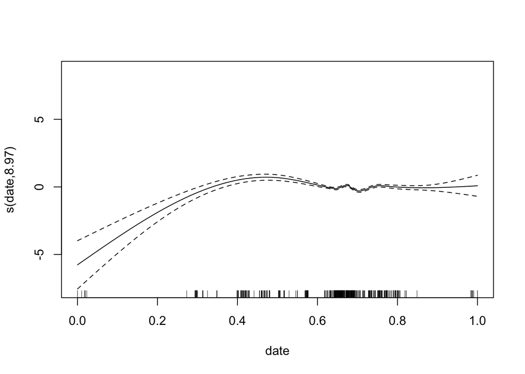

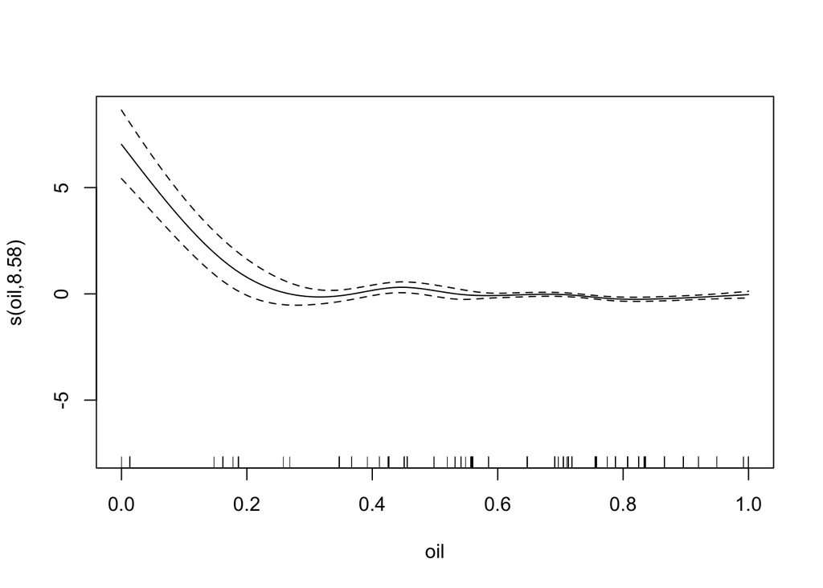

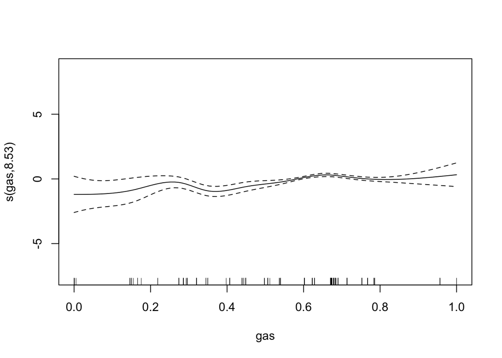

```r
plot(gam_v4)
```

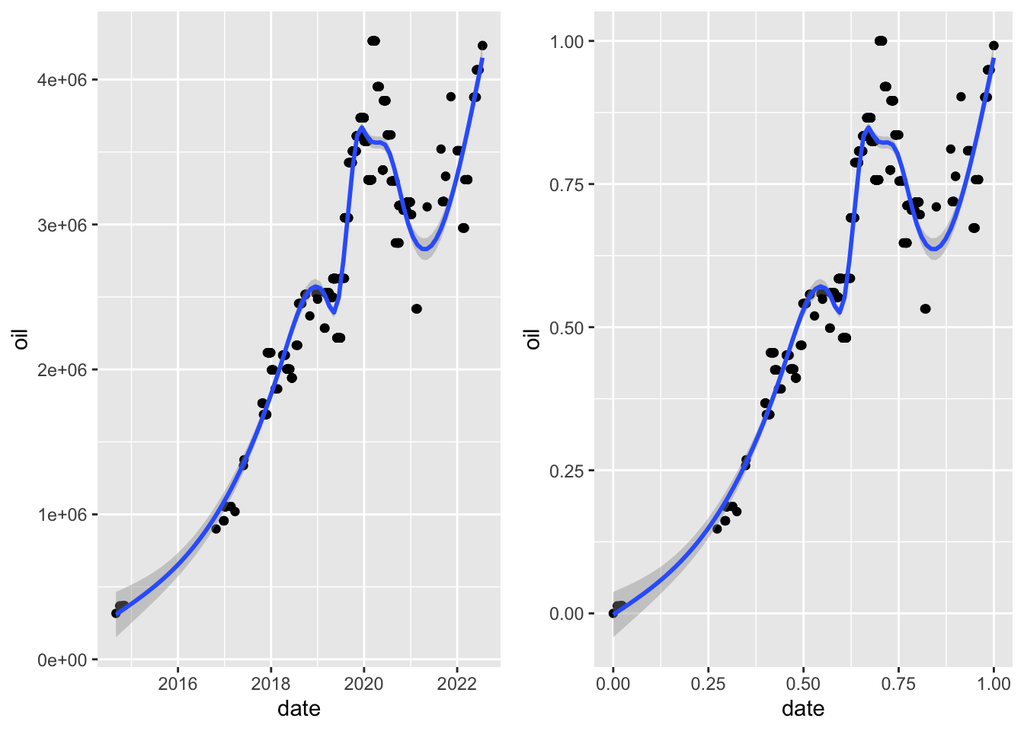

```r
# before transform
bt_oil <- ggplot(pb_vnf_complete, aes(date, oil)) +
  geom_point() +
  geom_smooth(method = "gam")
# after transform
at_oil <- ggplot(transformed, aes(date, oil)) +
  geom_point() +
  geom_smooth(method = "gam")

grid.arrange(bt_oil, at_oil, ncol = 2)
```

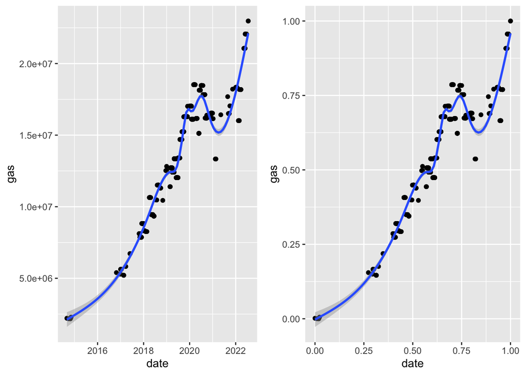

```r
# before transform
bt_gas <- ggplot(pb_vnf_complete, aes(date, gas)) +
  geom_point() +
  geom_smooth(method = "gam")
# after transform
at_gas <- ggplot(transformed, aes(date, gas)) +
  geom_point() +
  geom_smooth(method = "gam")

grid.arrange(bt_gas, at_gas, ncol = 2)
```

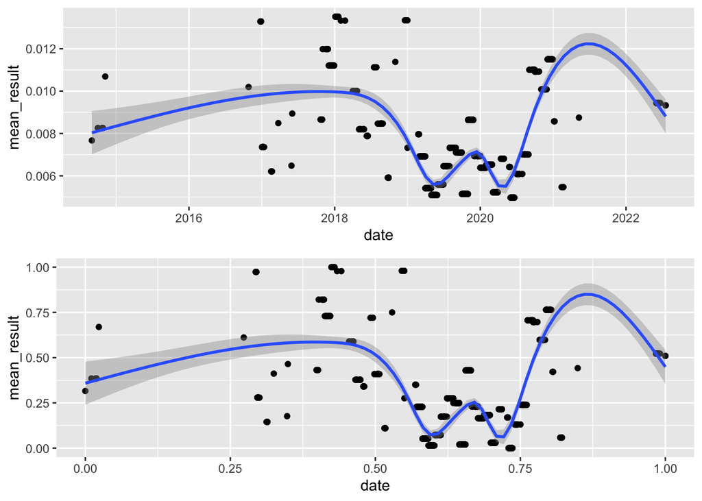

```r
# before transform
bt_GB <- ggplot(pb_vnf_complete, aes(date, mean_result)) +
  geom_point(na.rm = TRUE) +
  geom_smooth(method = "gam", na.rm = TRUE)
# after transform
at_GB <- ggplot(transformed, aes(date, mean_result)) +
  geom_point(na.rm = TRUE) +
  geom_smooth(method = "gam", na.rm = TRUE)
grid.arrange(bt_GB, at_GB, nrow = 2)
```

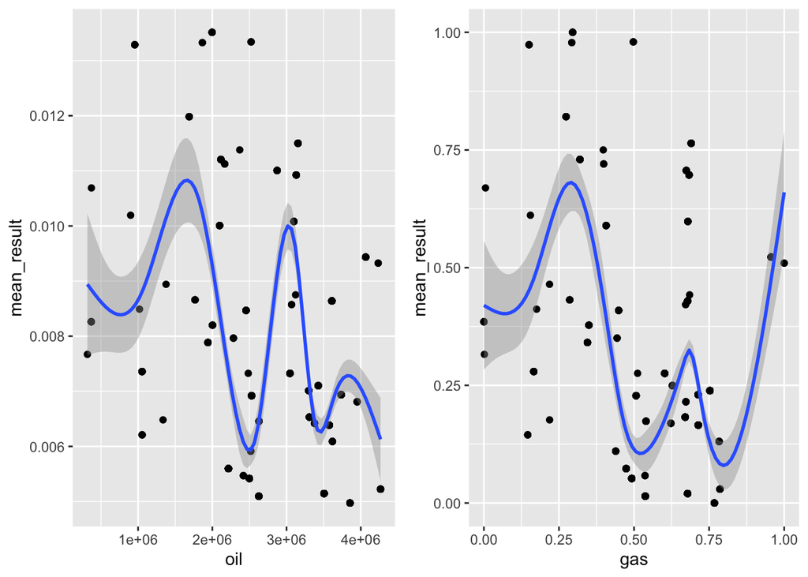

```r
at_oil_m <- ggplot(pb_vnf_complete, aes(oil, mean_result)) +
  geom_point() +
  geom_smooth(method = "gam")
at_gas_m <- ggplot(transformed, aes(gas, mean_result)) +
  geom_point() +
  geom_smooth(method = "gam")

grid.arrange(at_oil_m, at_gas_m, ncol = 2)
```

# Fit on GB daily

```r
GB_daily <- GB %>% filter(Location == "CARLSBAD") %>% select(Sample.Date, Result) %>% mutate(date = as.Date(Sample.Date)) %>% select(-Sample.Date)

pb_vnf_daily <- pb_vnf_complete %>% select(-mean_result) %>% group_by(date) %>%
  summarize(distToCarls = mean(distToCarls),
            temp_bb = mean(temp_bb),
            rhi = mean(rhi),
            area_bb = mean(area_bb),
            mean_solar = mean(mean_solar), # belows should have no change since they're already daily
            mean_temp = mean(mean_temp),
            mean_ws = mean(mean_ws),
            oil = mean(oil),
            gas = mean(gas),
            nox = mean(nox),
            o3 = mean(o3),
            season = Mode(season),
            month_count = mean(month_count),
            day_count = mean(day_count))
```

```r
GB_daily_complete <- merge(x = GB_daily,
                          y = pb_vnf_daily,
                          by.x = "date",
                          by.y = "date",
                          all.x = FALSE,
                          all.y = FALSE)
```

```r
# Modeling with GB_daily
lm_gb <- lm(Result * 1000 ~ ., data=GB_daily_complete)
summary(lm_gb)
```

```
##
## Call:
## lm(formula = Result * 1000 ~ ., data = GB_daily_complete)
##
## Residuals:
##     Min      1Q  Median      3Q     Max
## -5.7344 -1.7517 -0.4321  1.2835 12.2456
##
## Coefficients:
##                Estimate Std. Error t value Pr(>|t|)
## (Intercept)   2.950e+00  1.474e+02   0.020   0.9842
## date          7.068e-04  8.647e-03   0.082   0.9354
## distToCarls  -2.689e-02  6.314e-01  -0.043   0.9663
## temp_bb      -3.816e-03  5.979e-03  -0.638   0.5280
## rhi           6.460e-01  9.592e-01   0.673   0.5056
## area_bb      -3.147e-01  6.404e-01  -0.491   0.6266
## mean_solar   -1.651e-02  1.858e-02  -0.888   0.3812
## mean_temp     3.999e-03  1.941e-01   0.021   0.9837
## mean_ws      -4.327e-01  4.298e-01  -1.007   0.3218
## oil          -1.950e-06  3.984e-06  -0.489   0.6280
## gas           2.896e-07  1.448e-06   0.200   0.8428
## nox           3.161e-01  1.619e-01   1.953   0.0599 .
## o3            1.449e+02  1.298e+02   1.116   0.2730
## seasonSpring  3.159e-01  3.193e+00   0.099   0.9218
## seasonSummer -3.346e-01  2.885e+00  -0.116   0.9084
## seasonWinter -4.312e-01  2.811e+00  -0.153   0.8791
## month_count  -4.315e-02  7.233e-02  -0.597   0.5552
## day_count     4.483e-01  6.634e-01   0.676   0.5042
## ---
## Signif. codes:  0 '***' 0.001 '**' 0.01 '*' 0.05 '.' 0.1 ' ' 1
##
## Residual standard error: 3.841 on 31 degrees of freedom
##   (28 observations deleted due to missingness)
## Multiple R-squared:  0.3349, Adjusted R-squared:  -0.02986
## F-statistic: 0.9181 on 17 and 31 DF,  p-value: 0.5617
```

```r
gam_gb <- gam(Result * 1000 ~ date + distToCarls + temp_bb + rhi + area_bb + mean_solar + mean_temp + mean_ws + oil + gas +month_count + day_count , data=GB_daily_complete)
summary(gam_gb)
```

```
##
## Family: gaussian
## Link function: identity
##
## Formula:
## Result * 1000 ~ date + distToCarls + temp_bb + rhi + area_bb +
##     mean_solar + mean_temp + mean_ws + oil + gas + month_count +
##     day_count
##
## Parametric coefficients:
##               Estimate Std. Error t value Pr(>|t|)
## (Intercept) -3.478e-04  8.052e-04  -0.432    0.668
## date         1.075e-03  7.077e-04   1.519    0.136
## distToCarls -1.142e-01  5.143e-01  -0.222    0.825
## temp_bb     -2.097e-03  4.641e-03  -0.452    0.654
## rhi          9.921e-02  7.571e-01   0.131    0.896
## area_bb      2.090e-01  3.966e-01   0.527    0.601
## mean_solar  -1.066e-02  1.134e-02  -0.940    0.352
## mean_temp   -3.447e-03  8.836e-02  -0.039    0.969
## mean_ws     -4.040e-01  3.049e-01  -1.325    0.192
## oil         -1.594e-06  2.994e-06  -0.533    0.597
## gas          2.033e-07  5.735e-07   0.354    0.725
## month_count -7.142e-02  4.749e-02  -1.504    0.140
## day_count    9.733e-02  5.774e-01   0.169    0.867
##
##
## Rank: 12/13
## R-sq.(adj) =  0.0324   Deviance explained = 22.6%
## GCV = 16.146  Scale est. = 12.686    n = 56
```

```r
gam_gb_v1.5 <- gam(Result * 1000 ~ s(as.numeric(date), bs="cr") + distToCarls + temp_bb + rhi + area_bb + mean_solar + mean_temp + mean_ws + s(oil, bs="cr") + s(gas, bs="cr") + month_count + day_count, data=GB_daily_complete)
summary(gam_gb_v1.5)
```

```
##
## Family: gaussian
## Link function: identity
##
## Formula:
## Result * 1000 ~ s(as.numeric(date), bs = "cr") + distToCarls +
##     temp_bb + rhi + area_bb + mean_solar + mean_temp + mean_ws +
##     s(oil, bs = "cr") + s(gas, bs = "cr") + month_count + day_count
##
## Parametric coefficients:
##               Estimate Std. Error t value Pr(>|t|)
## (Intercept)  7.9999578 10.1845328   0.786    0.437
## distToCarls -0.1358825  0.4778011  -0.284    0.778
## temp_bb      0.0009976  0.0041514   0.240    0.811
## rhi          0.4223643  0.6595707   0.640    0.526
## area_bb      0.1989855  0.3406946   0.584    0.562
## mean_solar  -0.0033290  0.0102205  -0.326    0.746
## mean_temp   -0.0237305  0.0753082  -0.315    0.754
## mean_ws     -0.3139115  0.2696956  -1.164    0.251
## month_count  0.0192415  0.0521526   0.369    0.714
## day_count   -0.0523514  0.4992775  -0.105    0.917
##
## Approximate significance of smooth terms:
##                        edf Ref.df     F p-value
## s(as.numeric(date)) 0.7628 0.7611 3.734  0.0994 .
## s(oil)              4.3658 5.3203 3.144  0.0137 *
## s(gas)              0.3469 0.3485 0.259  0.7653
## ---
## Signif. codes:  0 '***' 0.001 '**' 0.01 '*' 0.05 '.' 0.1 ' ' 1
##
## Rank: 36/37
## R-sq.(adj) =  0.297   Deviance explained = 48.2%
## GCV =  12.73  Scale est. = 9.2185    n = 56
```

```r
gam_gb_v2 <- gam(Result * 1000 ~ s(as.numeric(date), bs="cr") + distToCarls + temp_bb + rhi + area_bb + mean_solar + mean_temp + mean_ws + s(oil, bs="cr") + s(gas, bs="cr") + month_count + day_count + season + o3 + nox, data=GB_daily_complete)
summary(gam_gb_v2)
```

```
##
## Family: gaussian
## Link function: identity
##
## Formula:
## Result * 1000 ~ s(as.numeric(date), bs = "cr") + distToCarls +
##     temp_bb + rhi + area_bb + mean_solar + mean_temp + mean_ws +
##     s(oil, bs = "cr") + s(gas, bs = "cr") + month_count + day_count +
##     season + o3 + nox
##
## Parametric coefficients:
##                Estimate Std. Error t value Pr(>|t|)
## (Intercept)    4.276396  15.011925   0.285    0.778
## distToCarls    0.303294   0.768362   0.395    0.696
## temp_bb       -0.001010   0.005577  -0.181    0.858
## rhi            1.123694   0.884625   1.270    0.216
## area_bb       -0.460163   0.614172  -0.749    0.461
## mean_solar    -0.005069   0.020115  -0.252    0.803
## mean_temp     -0.116335   0.193328  -0.602    0.553
## mean_ws       -0.347802   0.418455  -0.831    0.414
## month_count    0.049299   0.100371   0.491    0.628
## day_count      0.165217   0.622107   0.266    0.793
## seasonSpring   0.285974   4.472527   0.064    0.950
## seasonSummer  -0.406103   3.548597  -0.114    0.910
## seasonWinter  -2.105129   2.997736  -0.702    0.489
## o3           150.248756 129.696663   1.158    0.258
## nox            0.224529   0.159087   1.411    0.171
##
## Approximate significance of smooth terms:
##                       edf Ref.df     F p-value
## s(as.numeric(date)) 1.000  1.000 0.041   0.842
## s(oil)              2.980  3.613 0.887   0.570
## s(gas)              5.141  5.876 0.185   0.977
##
## R-sq.(adj) =  0.213   Deviance explained = 59.2%
## GCV = 22.224  Scale est. = 11.284    n = 49
```

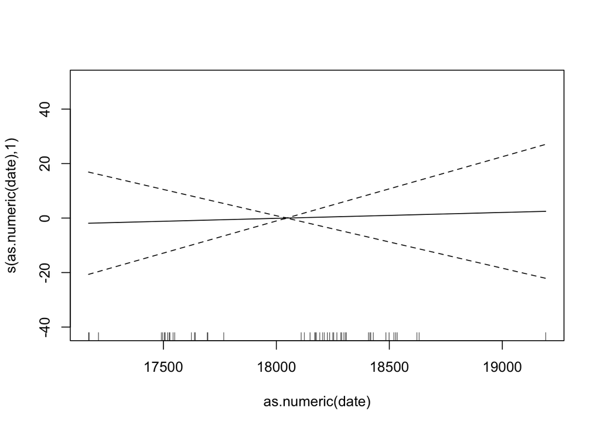

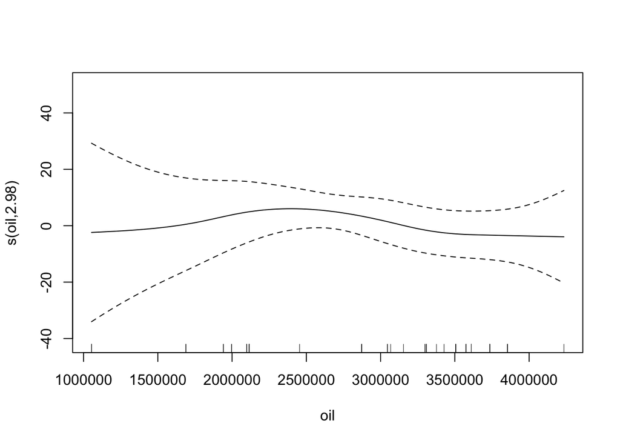

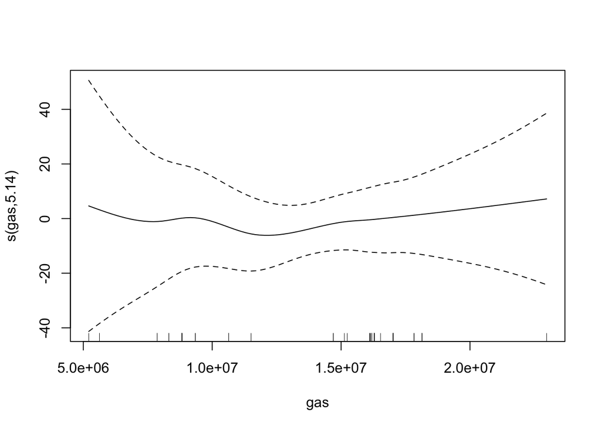

```r
plot(gam_gb_v2)
```

```r
# according to the performance of the models, there should be problems with multicollinearity and concurvity
vif(lm_gb)
```

```
##                   GVIF Df GVIF^(1/(2*Df))
## date         49.974610  1        7.069272
## distToCarls   1.704573  1        1.305593
## temp_bb       1.989698  1        1.410567
## rhi           5.498696  1        2.344930
## area_bb       8.086354  1        2.843652
## mean_solar    6.881069  1        2.623179
## mean_temp    12.376182  1        3.517980
## mean_ws       2.026401  1        1.423517
## oil          36.800978  1        6.066381
## gas         123.212034  1       11.100092
## nox           2.265628  1        1.505200
## o3            5.799073  1        2.408127
## season       30.918601  3        1.771618
## month_count   6.511297  1        2.551724
## day_count     1.583884  1        1.258525
```

```r
concurvity(gam_gb_v2, full = FALSE)
```

```
## $worst
##                             para s(as.numeric(date))       s(oil)       s(gas)
## para                1.000000e+00        3.630337e-33 2.114850e-31 2.229400e-31
## s(as.numeric(date)) 1.421887e-31        1.000000e+00 9.992986e-01 9.999561e-01
## s(oil)              2.184172e-31        9.992986e-01 1.000000e+00 9.992176e-01
## s(gas)              3.301909e-31        9.999561e-01 9.992176e-01 1.000000e+00
##
## $observed
##                             para s(as.numeric(date))       s(oil)       s(gas)
## para                1.000000e+00        6.768232e-35 3.385037e-33 6.066219e-33
## s(as.numeric(date)) 1.421887e-31        1.000000e+00 8.565499e-01 7.646507e-01
## s(oil)              2.184172e-31        9.440781e-01 1.000000e+00 7.621213e-01
## s(gas)              3.301909e-31        9.472532e-01 7.629962e-01 1.000000e+00
##
## $estimate
##                             para s(as.numeric(date))       s(oil)       s(gas)
## para                1.000000e+00        4.735162e-34 1.473315e-32 1.562005e-32
## s(as.numeric(date)) 1.421887e-31        1.000000e+00 5.537755e-01 6.450956e-01
## s(oil)              2.184172e-31        4.735197e-01 1.000000e+00 3.685506e-01
## s(gas)              3.301909e-31        5.185491e-01 5.520543e-01 1.000000e+00
```

```r
# repeatedly removing the predictor of lowest significance
gam_gb_v3 <- gam(Result ~  + rhi + s(oil, bs="cr") + s(gas, bs="cr")  + nox, data=GB_daily_complete)
summary(gam_gb_v3)
```

```
##
## Family: gaussian
## Link function: identity
##
## Formula:
## Result ~ +rhi + s(oil, bs = "cr") + s(gas, bs = "cr") + nox
##
## Parametric coefficients:
##              Estimate Std. Error t value Pr(>|t|)
## (Intercept) 5.618e-03  6.759e-04   8.312 6.83e-11 ***
## rhi         8.876e-04  3.066e-04   2.895  0.00567 **
## nox         1.523e-04  8.067e-05   1.888  0.06506 .
## ---
## Signif. codes:  0 '***' 0.001 '**' 0.01 '*' 0.05 '.' 0.1 ' ' 1
##
## Approximate significance of smooth terms:
##          edf Ref.df     F p-value
## s(oil) 4.514  5.459 3.005 0.01855 *
## s(gas) 6.925  7.702 3.259 0.00441 **
## ---
## Signif. codes:  0 '***' 0.001 '**' 0.01 '*' 0.05 '.' 0.1 ' ' 1
##
## R-sq.(adj) =  0.469   Deviance explained = 58.4%
## GCV = 8.7211e-06  Scale est. = 6.7222e-06  n = 63
```

```r
concurvity(gam_gb_v3, full = FALSE)
```

```
## $worst
##                para       s(oil)       s(gas)
## para   1.000000e+00 8.569543e-32 2.743152e-31
## s(oil) 1.377376e-31 1.000000e+00 9.985866e-01
## s(gas) 3.656699e-31 9.985866e-01 1.000000e+00
##
## $observed
##                para       s(oil)       s(gas)
## para   1.000000e+00 6.248844e-33 3.703075e-32
## s(oil) 1.377376e-31 1.000000e+00 9.314107e-01
## s(gas) 3.656699e-31 8.827335e-01 1.000000e+00
##
## $estimate
##                para       s(oil)       s(gas)
## para   1.000000e+00 1.110374e-32 2.553876e-32
## s(oil) 1.377376e-31 1.000000e+00 5.083273e-01
## s(gas) 3.656699e-31 5.337808e-01 1.000000e+00
```

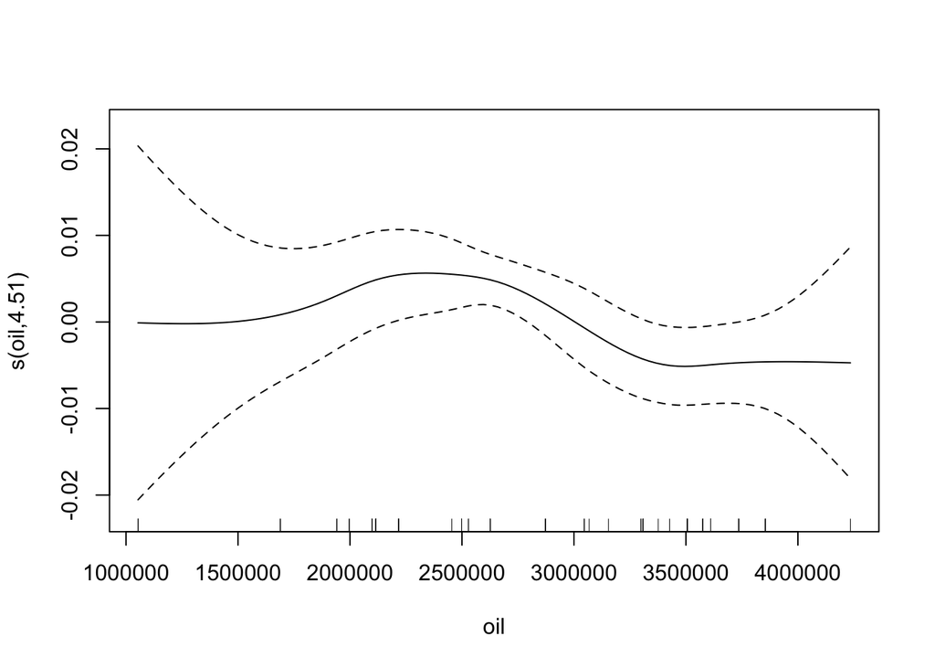

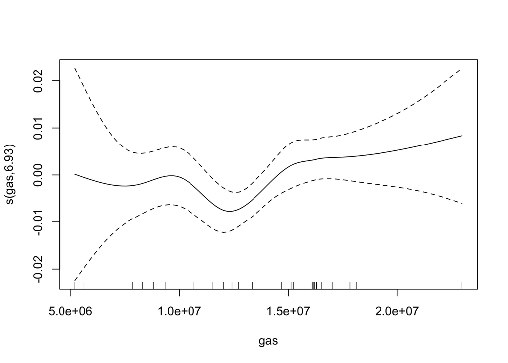

```r
plot(gam_gb_v3)
```

## GB flare counts only

```r
# including every GB observation even if flaring didn't happen on that day (0 for count)
GB_daily_count <- merge(x = GB_daily,
                          y = weather_daily,
                          by.x = "date",
                          by.y = "date",
                          all.x = FALSE,
                          all.y = FALSE)
```

```r
GB_daily_count <- merge(x = GB_daily_count,
                        y = vnf_day_counts,
                        by.x = "date",
                        by.y = "date",
                        all.x = TRUE,
                        all.y = FALSE)
```

```r
GB_daily_count$day_count[is.na(GB_daily_count$day_count)] <- 0
```

```r
colSums(is.na(GB_daily_count))
```

```
##                date              Result          mean_solar           mean_temp
##                   0                   0                  67                  68
##             mean_ws                 oil                 gas                  o3
##                  67                  17                  17                 108
##                PM25                 nox              season most_wind_direction
##                 499                 130                   0                  34
##           day_count
##                   0
```

```r
gam_gb_count <- gam(Result * 1000 ~ s(as.numeric(date), bs="cr") + mean_solar + mean_temp + mean_ws + s(oil, bs="cr") + s(gas, bs="cr") + PM25 + most_wind_direction + day_count + season + o3 + nox, data = GB_daily_count)
summary(gam_gb_count)
```

```
##
## Family: gaussian
## Link function: identity
##
## Formula:
## Result * 1000 ~ s(as.numeric(date), bs = "cr") + mean_solar +
##     mean_temp + mean_ws + s(oil, bs = "cr") + s(gas, bs = "cr") +
##     PM25 + most_wind_direction + day_count + season + o3 + nox
##
## Parametric coefficients:
##                       Estimate Std. Error t value Pr(>|t|)
## (Intercept)           14.42683    3.88605   3.712 0.000294 ***
## mean_solar             0.00277    0.01021   0.271 0.786644
## mean_temp             -0.04448    0.11654  -0.382 0.703305
## mean_ws               -0.18999    0.56160  -0.338 0.735635
## PM25                   0.31133    0.15385   2.024 0.044883 *
## most_wind_directionQ2 -0.70404    2.17004  -0.324 0.746085
## most_wind_directionQ3 -1.01239    2.29284  -0.442 0.659489
## most_wind_directionQ4 -0.96971    2.16203  -0.449 0.654459
## day_count              0.00000    0.00000     NaN      NaN
## seasonSpring          -3.84104    1.81948  -2.111 0.036516 *
## seasonSummer          -3.68204    1.80735  -2.037 0.043478 *
## seasonWinter          -3.54042    1.92621  -1.838 0.068145 .
## o3                     0.37004    0.10810   3.423 0.000808 ***
## nox                    0.40030    0.35220   1.137 0.257632
## ---
## Signif. codes:  0 '***' 0.001 '**' 0.01 '*' 0.05 '.' 0.1 ' ' 1
##
## Approximate significance of smooth terms:
##                        edf Ref.df      F  p-value
## s(as.numeric(date)) 5.3225 5.7975  6.389  0.00013 ***
## s(oil)              0.4402 0.4426 37.401 7.83e-05 ***
## s(gas)              0.9840 0.9836  0.009  0.92694
## ---
## Signif. codes:  0 '***' 0.001 '**' 0.01 '*' 0.05 '.' 0.1 ' ' 1
##
## Rank: 38/41
## R-sq.(adj) =  0.219   Deviance explained = 30.6%
## GCV = 35.142  Scale est. = 31.056    n = 161
```

```r
gam_gb_count_v2 <- gam(Result  ~ s(as.numeric(date), bs="cr") + mean_solar  + mean_ws + s(oil, bs="cr") + s(gas, bs="cr") + day_count + season + o3 + nox, data = GB_daily_count)
summary(gam_gb_count_v2)
```

```
##
## Family: gaussian
## Link function: identity
##
## Formula:
## Result ~ s(as.numeric(date), bs = "cr") + mean_solar + mean_ws +
##     s(oil, bs = "cr") + s(gas, bs = "cr") + day_count + season +
##     o3 + nox
##
## Parametric coefficients:
##                Estimate Std. Error t value Pr(>|t|)
## (Intercept)   1.036e-02  1.266e-03   8.178 2.58e-15 ***
## mean_solar    1.365e-06  3.678e-06   0.371  0.71065
## mean_ws       3.044e-05  1.886e-04   0.161  0.87188
## day_count    -2.024e-04  3.655e-04  -0.554  0.58001
## seasonSpring -1.741e-03  6.216e-04  -2.801  0.00530 **
## seasonSummer -1.572e-03  6.404e-04  -2.455  0.01442 *
## seasonWinter -1.576e-03  5.926e-04  -2.660  0.00808 **
## o3           -1.584e-02  3.147e-02  -0.503  0.61494
## nox           2.676e-04  8.248e-05   3.245  0.00126 **
## ---
## Signif. codes:  0 '***' 0.001 '**' 0.01 '*' 0.05 '.' 0.1 ' ' 1
##
## Approximate significance of smooth terms:
##                       edf Ref.df      F p-value
## s(as.numeric(date)) 2.934  3.743 25.799  <2e-16 ***
## s(oil)              1.023  1.035  1.064   0.292
## s(gas)              2.002  2.378  0.951   0.518
## ---
## Signif. codes:  0 '***' 0.001 '**' 0.01 '*' 0.05 '.' 0.1 ' ' 1
##
## R-sq.(adj) =  0.291   Deviance explained = 31.1%
## GCV = 1.8705e-05  Scale est. = 1.8142e-05  n = 497
```